# Where the variation lies

Four descriptions of the protein data, none of them a test of HR against LR in mean abundance: how much of each protein’s variation belongs to person, time, group and blood (variancePartition); whether one group varies more between people (DiffVar, exploratory); whether the biopsies fall into natural clusters (gap statistic); and what drives the main axes of variation (principal components against covariates). They feed supplement S1.

## Packages

variancePartition fits the variance shares, missMethyl’s `varFit()` the variability test, cluster the gap statistic and PAM.

```r
library(here)
library(dplyr)
library(tidyr)
library(purrr)
library(ggplot2)
library(variancePartition)
source(here("00_Setup", "Shared_functions", "workbooks.R"))
inputs <- c(
  proteins = "01_Processing/02_Quantification/c_data/quantification.rds",
  corrected = "01_Processing/03_Blood_Correction/c_data/blood_correction.rds",
  fit = "02_HRvLR/01_Protein_Contrasts/c_data/protein_contrasts.rds"
)
paths <- vapply(inputs, here, character(1))
stopifnot(file.exists(paths))
```

## Input

```r
proteins <- readRDS(paths[["proteins"]])
corrected <- readRDS(paths[["corrected"]])
meta <- as_tibble(proteins$targets) |>
  mutate(
    weight = readRDS(paths[["fit"]])$fit$targets$sample.weight,
    proteins_detected = colSums(proteins$other$n.observations > 0)
  )
c(proteins = nrow(proteins), biopsies = ncol(proteins))
```

```
proteins biopsies
    2059       48
```

## Variance shares

`fitExtractVarPartModel()` fits one linear mixed model per protein, with person, time point and group as random effects and blood as a fixed covariate, and reports the share of the protein’s variance each explains; the rest is residual. Group is constant within a person, so its share is the part of the between-person variation that HR and LR explain. limpa’s precision weights (1/SE²) are used.

```r
vp_data <- as.data.frame(meta)
vp_formula <- ~ (1 | subject) + (1 | timepoint) + (1 | group) + blood
variance_shares <- fitExtractVarPartModel(
  proteins$E, vp_formula, vp_data,
  weights = 1 / proteins$other$standard.error^2
) |>
  as.data.frame() |>
  as_tibble(rownames = "uniprot_id")
variance_shares |>
  summarise(across(-uniprot_id, median)) |>
  round(3)
```

```
# A tibble: 1 × 5
  group subject timepoint blood Residuals
  <dbl>   <dbl>     <dbl> <dbl>     <dbl>
1     0   0.125         0  0.02      0.79
```

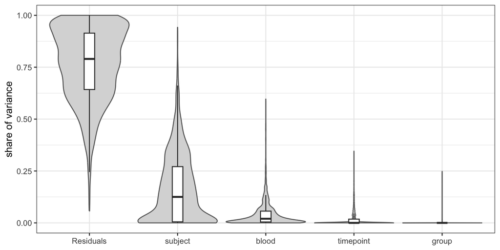

Figure 1: Share of each protein’s variance by source (variancePartition).

```r
variance_shares |>
  pivot_longer(-uniprot_id, names_to = "source", values_to = "share") |>
  ggplot(aes(reorder(source, -share, median), share)) +
  geom_violin(fill = "grey85", colour = "grey40", scale = "width") +
  geom_boxplot(width = 0.12, outlier.shape = NA) +
  labs(x = NULL, y = "share of variance") +
  theme_bw(base_size = 10)
```

## Is one group more variable?

DiffVar (Phipson and Oshlack 2014, missMethyl’s `varFit()`) tests whether people in one group spread more widely than in the other, one time point at a time. It works on each value’s absolute deviation from its group median, moderated as in limma. limpa’s modelled values for a protein no precursor was seen in carry little spread, so a group that never observed a protein looks uniform: the test then reads detection, not variability. It runs only on proteins observed in every biopsy of both groups at that time point. With 8 people per group this is exploratory: low power, and a hit is a lead, not a finding.

```r
diffvar <- map(set_names(c("T1", "T2", "T3")), \(tp) {
  rows <- meta$timepoint == tp
  complete <- rowSums(proteins$other$n.observations[, rows] > 0) == sum(rows)
  design <- model.matrix(~ group, meta[rows, ])
  fit <- missMethyl::varFit(proteins$E[complete, rows], design = design, coef = c(1, 2))
  missMethyl::topVar(fit, coef = 2, number = sum(complete), sort = FALSE) |>
    as_tibble(rownames = "uniprot_id") |>
    transmute(uniprot_id, log_var_ratio = LogVarRatio, p = P.Value, fdr = Adj.P.Value)
}) |>
  list_rbind(names_to = "timepoint")
diffvar |>
  summarise(
    more_variable_hr = sum(p < 0.05 & log_var_ratio < 0),
    more_variable_lr = sum(p < 0.05 & log_var_ratio > 0),
    tested = n(), fdr_05 = sum(fdr < 0.05), .by = timepoint
  )
```

```
# A tibble: 3 × 5
  timepoint more_variable_hr more_variable_lr tested fdr_05
  <chr>                <int>            <int>  <int>  <int>
1 T1                      50               11   1076      0
2 T2                      31               36    870      0
3 T3                      87                5    673      0
```

`log_var_ratio` is LR relative to HR (the second level against the first): positive means LR people spread more.

## Do the biopsies form natural clusters?

The blood-corrected values, proteins scaled, are reduced to their first 10 principal components. The gap statistic (Tibshirani, Walther and Hastie 2001; `cluster::clusGap()` with PAM, 100 reference data sets) compares how tight k clusters are against data with no group structure; the one-standard-error rule (`Tibs2001SEmax`) picks the smallest k whose gap is at least the next k’s gap minus that gap’s standard error. k = 1 means no natural clusters. The question is asked of all 48 biopsies, of each time point alone, and of each person’s training (T2 − T1) and acute (T3 − T2) change. A second check forces the biopsies into two PAM clusters and asks whether those match HR and LR: the adjusted Rand index (Hubert and Arabie 1985; `mclust::adjustedRandIndex()`) is 1 for a perfect match and about 0 for chance. The biopsy correlation matrix, ordered by hierarchical clustering, shows the same question as a picture.

```r
scaled <- scale(t(corrected$E))
gap_of <- \(x) {
  set.seed(1)
  gap <- cluster::clusGap(
    x, FUNcluster = \(x, k) list(cluster = cluster::pam(x, k, cluster.only = TRUE)),
    K.max = 6, B = 100, verbose = FALSE
  )
  as_tibble(gap$Tab) |>
    mutate(k = row_number(), .before = 1) |>
    select(k, gap, se = SE.sim)
}
at_time <- \(tp) {
  rows <- meta$timepoint == tp
  set_names(as.data.frame(corrected$E[, rows]), meta$subject[rows])[, unique(meta$subject)]
}
windows <- list(
  all = as.data.frame(corrected$E), T1 = at_time("T1"), T2 = at_time("T2"), T3 = at_time("T3"),
  Training = at_time("T2") - at_time("T1"), Acute = at_time("T3") - at_time("T2")
)
group_of <- set_names(c(meta$group, meta$group), c(meta$sample_id, meta$subject))
# Proteins with no spread in a window (one modelled value for everyone) are left out of it.
n_pcs <- 10
pcs <- map(windows, \(x) {
  x <- t(as.matrix(x))
  prcomp(scale(x[, apply(x, 2, sd) > 0]))$x[, seq_len(n_pcs)]
})
gaps <- map(pcs, gap_of)
separation <- imap(pcs, \(x, w) {
  split <- cluster::pam(x, 2, cluster.only = TRUE)
  tibble(
    n_biopsies = nrow(x), n_pcs = ncol(x),
    k_gap = cluster::maxSE(gaps[[w]]$gap, gaps[[w]]$se, method = "Tibs2001SEmax"),
    ari_group = mclust::adjustedRandIndex(split, group_of[rownames(x)]),
    smaller_cluster = min(table(split))
  )
}) |>
  list_rbind(names_to = "window")
gap_table <- gaps$all
k_chosen <- separation$k_gap[separation$window == "all"]
separation
```

```
# A tibble: 6 × 6
  window   n_biopsies n_pcs k_gap ari_group smaller_cluster
  <chr>         <int> <int> <int>     <dbl>           <int>
1 all              48    10     1  -0.00543              21
2 T1               16    10     1  -0.0667                6
3 T2               16    10     1   0                     1
4 T3               16    10     1   0                     1
5 Training         16    10     1   0                     1
6 Acute            16    10     1   0                     1
```

```r
biopsy_correlation <- cor(t(scaled))
order_rows <- hclust(as.dist(1 - biopsy_correlation), method = "average")$order
correlation_long <- as_tibble(biopsy_correlation, rownames = "sample_a") |>
  pivot_longer(-sample_a, names_to = "sample_b", values_to = "r")
```

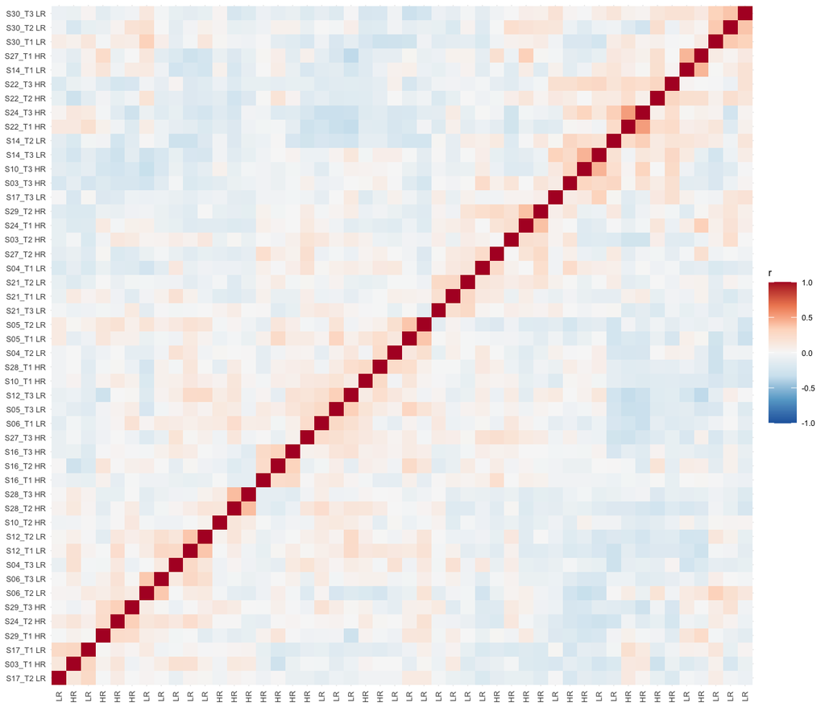

Figure 2: Biopsy correlation, ordered by average-linkage clustering; axis labels by group.

```r
ordered <- rownames(biopsy_correlation)[order_rows]
group_of <- set_names(meta$group, meta$sample_id)
correlation_long |>
  mutate(sample_a = factor(sample_a, ordered), sample_b = factor(sample_b, ordered)) |>
  ggplot(aes(sample_a, sample_b, fill = r)) +
  geom_tile() +
  scale_fill_distiller(palette = "RdBu", limits = c(-1, 1), name = "r") +
  scale_x_discrete(labels = \(x) group_of[x]) +
  scale_y_discrete(labels = \(x) paste(x, group_of[x])) +
  labs(x = NULL, y = NULL) +
  theme_minimal(base_size = 6) +
  theme(axis.text.x = element_text(angle = 90, vjust = 0.5))
```

## What drives the main axes?

For each of the first five principal components of the blood-corrected values, the share of its variance (R²) each covariate explains alone: time point, group, person, blood, proteins detected and sample weight. A technical covariate on PC1 means the largest variation is technical.

```r
pca <- prcomp(scaled)
pc_scores <- as_tibble(pca$x[, 1:5], rownames = "sample_id") |>
  left_join(meta, by = "sample_id")
covariates <- c("timepoint", "group", "subject", "blood", "proteins_detected", "weight")
pc_covariates <- expand_grid(component = paste0("PC", 1:5), covariate = covariates) |>
  mutate(r2 = map2_dbl(component, covariate, \(pc, cv) {
    summary(lm(reformulate(cv, pc), data = pc_scores))$r.squared
  })) |>
  left_join(
    tibble(component = paste0("PC", 1:5), pc_share = summary(pca)$importance[2, 1:5]),
    by = "component"
  )
pc1_depth <- with(pc_covariates, r2[component == "PC1" & covariate == "proteins_detected"])
pc_covariates |>
  select(-pc_share) |>
  pivot_wider(names_from = covariate, values_from = r2) |>
  mutate(across(where(is.numeric), \(x) round(x, 2)))
```

```
# A tibble: 5 × 7
  component timepoint group subject blood proteins_detected weight
  <chr>         <dbl> <dbl>   <dbl> <dbl>             <dbl>  <dbl>
1 PC1            0.01  0.03    0.48  0.02              0.85   0.08
2 PC2            0.05  0.06    0.43  0.02              0.04   0.39
3 PC3            0.24  0.02    0.44  0.07              0.04   0.02
4 PC4            0.01  0.01    0.43  0                 0      0.02
5 PC5            0.14  0.13    0.72  0                 0      0.07
```

`subject` has 16 levels, so its R² is high by construction on any axis; read it against the others. Proteins detected explains 85% of PC1: the largest axis is technical. The two thin S28 biopsies, whose values are mostly estimated from limpa’s detection curve, sit at its extreme; methods without a model (PCA, PERMANOVA, modules, set scores, DiffVar) include them unweighted.

## Validation

```r
stopifnot(
  all(abs(rowSums(select(variance_shares, -uniprot_id)) - 1) < 1e-6),
  all(is.finite(diffvar$log_var_ratio)), k_chosen %in% 1:6,
  all(pc_covariates$r2 >= 0 & pc_covariates$r2 <= 1)
)
```

## Summary

The median protein owes 12.5% of its variance to person, 0% to time point and 0% to group. The gap statistic picks k = 1 across all biopsies and k = 1, 1, 1, 1, 1 for T1, T2, T3, Training, Acute; a forced two-cluster split matches HR/LR with an adjusted Rand index of -0.07, 0.00, 0.00, 0.00, 0.00.

## Save

```r
out <- here("02_HRvLR", "04_Variance", "c_data")
dir.create(out, showWarnings = FALSE)
write_workbook(
  list(
    variance_shares = variance_shares, diffvar = diffvar, gap = gap_table, separation = separation,
    biopsy_correlation = correlation_long,
    biopsy_order = tibble(
      sample_id = rownames(biopsy_correlation)[order_rows], position = seq_along(order_rows)
    ),
    pc_scores = pc_scores, pc_covariates = pc_covariates
  ),
  c(
    "Per protein: share of variance from person, time point, group, blood and residual.",
    "Per time point, proteins seen in all 16 biopsies: DiffVar log variance ratio (LR/HR), p, FDR.",
    "Gap statistic per k (PAM on 10 PCs, 100 reference sets) with its standard error.",
    "All biopsies, each time point and each change: gap k, forced two-cluster split against HR/LR.",
    "Pearson correlation between every pair of biopsies, blood-corrected values scaled.",
    "Biopsy order from average-linkage clustering of 1 - correlation.",
    "PC1 to PC5 per biopsy with its covariates.",
    "R² of each covariate on each of PCs 1 to 5, and each PC's share of variance."
  ),
  file.path(out, "variance.xlsx"), inputs, paths
)
```